# Problem 2

## Problem 2

We simulate the three autoregressive series using the given code.

```r
set.seed(4155)

n <- 400

x1 <- arima.sim(model = list(ar = 0.75), n = n)
x2 <- arima.sim(model = list(ar = -0.75), n = n)
x3 <- arima.sim(model = list(ar = c(1.2, -0.5)), n = n)
```

## (a) Time series plots

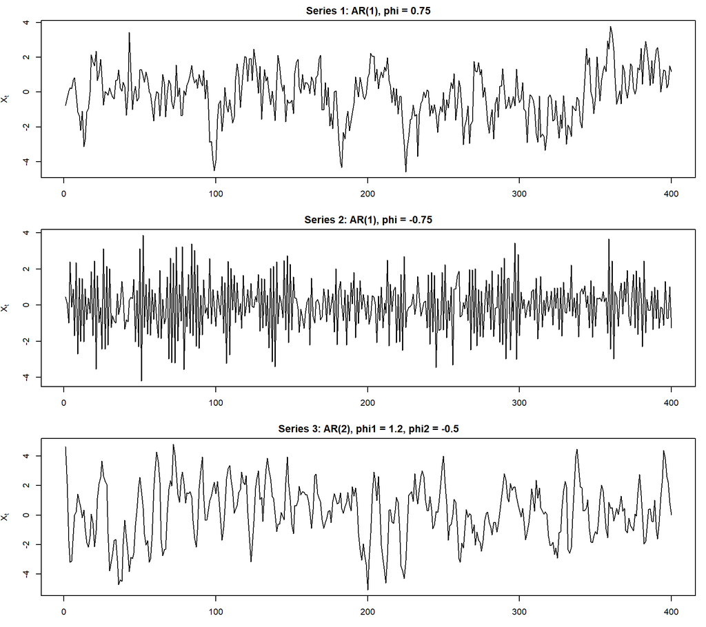

```r
par(mfrow = c(3, 1), mar = c(3, 4, 2, 1))

plot(x1, type = "l",
     main = "Series 1: AR(1), phi = 0.75",
     xlab = "Time", ylab = expression(X[t]))

plot(x2, type = "l",
     main = "Series 2: AR(1), phi = -0.75",
     xlab = "Time", ylab = expression(X[t]))

plot(x3, type = "l",
     main = "Series 3: AR(2), phi1 = 1.2, phi2 = -0.5",
     xlab = "Time", ylab = expression(X[t]))
```

```r
par(mfrow = c(1, 1))
```

For the first series, the positive AR coefficient $\phi=0.75$ produces strong positive persistence. Consecutive observations tend to have similar signs and values, so the series contains relatively long runs above or below its mean.

For the second series, the negative coefficient $\phi=-0.75$ causes successive observations to tend to have opposite signs. Therefore, the series exhibits a noticeable alternating or zig-zag pattern.

The third series is an AR(2) process. The combination of coefficients $\phi_1=1.2$ and $\phi_2=-0.5$ produces oscillatory behavior. Unlike Series 2, which tends to alternate at every observation, Series 3 tends to exhibit smoother waves or cycles that gradually change over time.

## (b) Sample ACF

We compute the sample autocorrelation functions through lag 24.

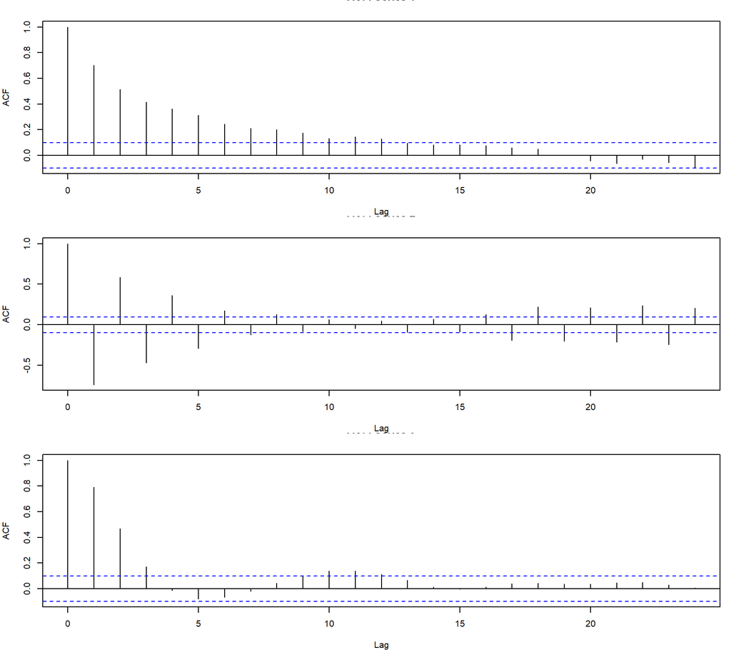

```r
par(mfrow = c(3, 1), mar = c(4, 4, 2, 1))

acf(x1, lag.max = 24,
    main = "ACF: Series 1")

acf(x2, lag.max = 24,
    main = "ACF: Series 2")

acf(x3, lag.max = 24,
    main = "ACF: Series 3")
```

```r
par(mfrow = c(1, 1))
```

For Series 1, the ACF decreases approximately smoothly and geometrically toward zero. For a theoretical AR(1) model with $\phi=0.75$,

$$\rho(h) = (0.75)^{|h|},$$

so the autocorrelations are positive and decay as the lag increases.

For Series 2,

$$\rho(h) = (-0.75)^{|h|}.$$

Thus, the ACF alternates in sign. The correlations are negative at odd lags and positive at even lags, while their magnitudes gradually decrease toward zero.

Series 3 has a damped oscillatory ACF. Its autocorrelations alternate in a more gradual wave-like fashion rather than simply changing sign at every lag. This behavior is characteristic of an AR(2) process having complex characteristic roots.

## (c) Why does the ACF of an AR process tail off?

For an AR process, the current observation depends on previous observations, which in turn depend on even earlier observations. Therefore, dependence is transmitted indirectly across many lags.

For example, for an AR(1) process

$$X_t = \phi X_{t-1} + W_t,$$

the theoretical ACF is

$$\rho(h) = \phi^{|h|}.$$

This contrasts with a moving-average process, for which the theoretical ACF becomes exactly zero after the order of the MA process.

Therefore, based only on the ACF plots, identifying the exact order of an AR model can be difficult. Several AR models can produce ACFs that decay in similar ways. The PACF is generally more useful for determining the order of an AR process because the theoretical PACF of an AR($p$) process cuts off after lag $p$.

## (d) Sample PACF

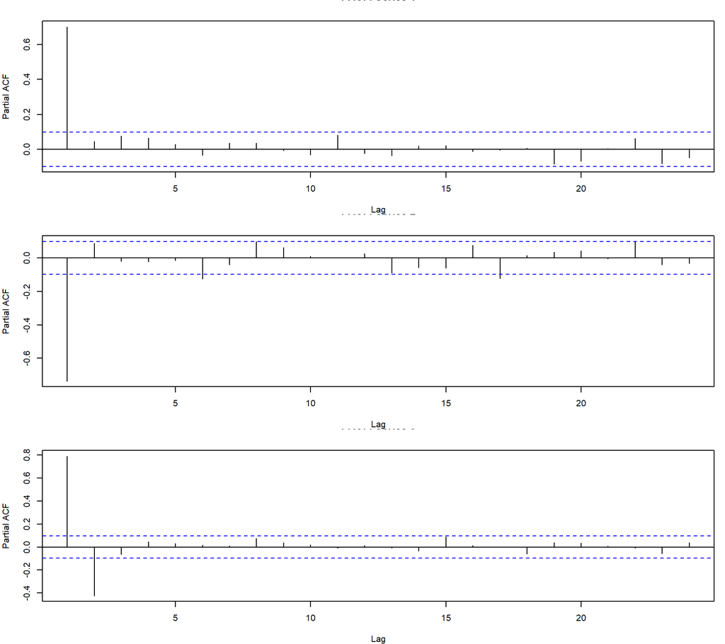

```r
par(mfrow = c(3, 1), mar = c(4, 4, 2, 1))

pacf(x1, lag.max = 24,
     main = "PACF: Series 1")

pacf(x2, lag.max = 24,
     main = "PACF: Series 2")

pacf(x3, lag.max = 24,
     main = "PACF: Series 3")
```

```r
par(mfrow = c(1, 1))
```

For Series 1, there is a prominent positive spike at lag 1. After lag 1, the remaining sample partial autocorrelations are generally small and mostly within the confidence bounds. Thus, the PACF appears to cut off after lag 1.

For Series 2, there is a prominent negative spike at lag 1. The remaining partial autocorrelations are generally small. Thus, its PACF also appears to cut off after lag 1.

For Series 3, prominent partial autocorrelations occur at lags 1 and 2. After lag 2, the remaining values are generally much smaller and fluctuate around zero. Therefore, its PACF appears to cut off after lag 2.

These patterns agree with the theoretical property that the PACF of an AR($p$) process is zero for lags greater than $p$.

## (e) Estimating the AR orders

From the PACF plots, the estimated orders are

$$\begin{array}{c|c}
\text{Series} & \text{Estimated AR order} \\
\hline
x_1 & 1 \\
x_2 & 1 \\
x_3 & 2
\end{array}$$

Thus, we identify

$$x_1 \sim AR(1), \qquad
x_2 \sim AR(1), \qquad
x_3 \sim AR(2).$$

An isolated significant PACF spike at a later lag does not necessarily mean that the process has a higher AR order. Sample autocorrelations and partial autocorrelations are random quantities. Even when the true population PACF is zero at a particular lag, sampling variability can cause the estimated PACF to exceed the approximate significance limits.

The commonly displayed approximate 95% confidence limits are

$$\pm \frac{1.96}{\sqrt{n}}.$$

For $n=400$, these limits are approximately

```r
1.96 / sqrt(n)
```

```
## [1] 0.098
```

or about

$$\pm 0.098.$$

Because many lags are being inspected simultaneously, it is possible for one or more later lags to cross these bounds simply by chance. Therefore, AR order should primarily be determined from the systematic pattern of the early PACF lags rather than from a single isolated significant spike at a large lag.